# ErythroCite database

# Figure_2: Phylogenetic tree with data

The following steps describe how to visualise the data associated with each trait and species within the phylogenetic tree. To accomplish this, we will first calculate mean values per species and trait, select the columns of interest, and standardise these values to enhance the colour contrast of the scale.

```r
# Summaries data: calculate the mean value per species for each trait
summary_data <- dat %>%
  group_by(species_underscored) %>%
  summarise(across(c(cell_area, cell_volume, nucleus_area, nucleus_volume, mcv),
                   ~ mean(., na.rm = TRUE)),
            .groups = "drop") %>%
  rename(
    "Cell area" = cell_area,
    "Cell volume" = cell_volume,
    "Nucleus area" = nucleus_area,
    "Nucleus volume" = nucleus_volume,
    "MCV" = mcv
  )

# Scale min-max global by variable
summary_data <- summary_data %>%
  mutate(across(c("Cell area", "Cell volume", "Nucleus area", "Nucleus volume", "MCV"),
                ~ (.-min(., na.rm = TRUE)) / (max(., na.rm = TRUE) - min(., na.rm = TRUE))))  # scale min-max global by variable
```

```r
# Script section adapted by FPLeiva after RMolinaVenegas (Gracias Rafa)
summary_data
```

```
## # A tibble: 660 × 6
##    species_underscored `Cell area` `Cell volume` `Nucleus area` `Nucleus volume`
##    <chr>                     <dbl>         <dbl>          <dbl>            <dbl>
##  1 Abalistes_stellatus      0.0298      NaN             0.0310         NaN
##  2 Abramis_brama            0.0465        0.0141      NaN              NaN
##  3 Abudefduf_saxatilis      0.0415        0.0128        0.00995        NaN
##  4 Abudefduf_septemfa…    NaN           NaN           NaN                0.00549
##  5 Abudefduf_sordidus       0.0738        0.0285        0.120            0.0561
##  6 Abudefduf_taurus         0.0460        0.0149      NaN              NaN
##  7 Abudefduf_vaigiens…      0.0769        0.0309        0.119            0.0538
##  8 Acanthocybium_sola…      0.0618        0.0193      NaN              NaN
##  9 Acanthogobius_hasta      0.0657        0.0230        0.110            0.0765
## 10 Acanthopagrus_aust…    NaN           NaN           NaN                0.0123
## # ℹ 650 more rows
## # ℹ 1 more variable: MCV <dbl>
```

```r
unique(summary_data$species_underscored)
```

```
##   [1] "Abalistes_stellatus"             "Abramis_brama"
##   [3] "Abudefduf_saxatilis"             "Abudefduf_septemfasciatus"
##   [5] "Abudefduf_sordidus"              "Abudefduf_taurus"
##   [7] "Abudefduf_vaigiensis"            "Acanthocybium_solandri"
##   [9] "Acanthogobius_hasta"             "Acanthopagrus_australis"
##  [11] "Acanthopagrus_butcheri"          "Acanthostracion_polygonius"
##  [13] "Acanthostracion_quadricornis"    "Acanthurus_bahianus"
##  [15] "Acanthurus_chirurgus"            "Acanthurus_coeruleus"
##  [17] "Acanthurus_gahhm"                "Acanthurus_grammoptilus"
##  [19] "Acipenser_brevirostrum"          "Acipenser_oxyrinchus"
##  [21] "Acipenser_sinensis"              "Acipenser_sturio"
##  [23] "Aeoliscus_strigatus"             "Aetobatus_narinari"
##  [25] "Albula_vulpes"                   "Aldrichetta_forsteri"
##  [27] "Alosa_fallax"                    "Alphestes_afer"
##  [29] "Aluterus_schoepfii"              "Aluterus_scriptus"
```

[output cut: 315 more lines]

```r
# Identify species to drop
species_to_drop <- setdiff(tree$tip.label, summary_data$species_underscored)

# Prune the tree
tree <- drop.tip(tree, species_to_drop)

# Align data and tree
datF <- summary_data %>%
  column_to_rownames("species_underscored")

dat_tree <- datF %>%
  filter(row.names(.) %in% tree$tip.label)

# Add missing species
missing_species <- setdiff(tree$tip.label, row.names(dat_tree))
dat_tree_NA <- data.frame(matrix(NA, nrow = length(missing_species), ncol = ncol(datF)))
row.names(dat_tree_NA) <- missing_species
colnames(dat_tree_NA) <- colnames(datF)
Data <- rbind(dat_tree, dat_tree_NA)
Data <- Data[match(tree$tip.label, row.names(Data)), ]
```

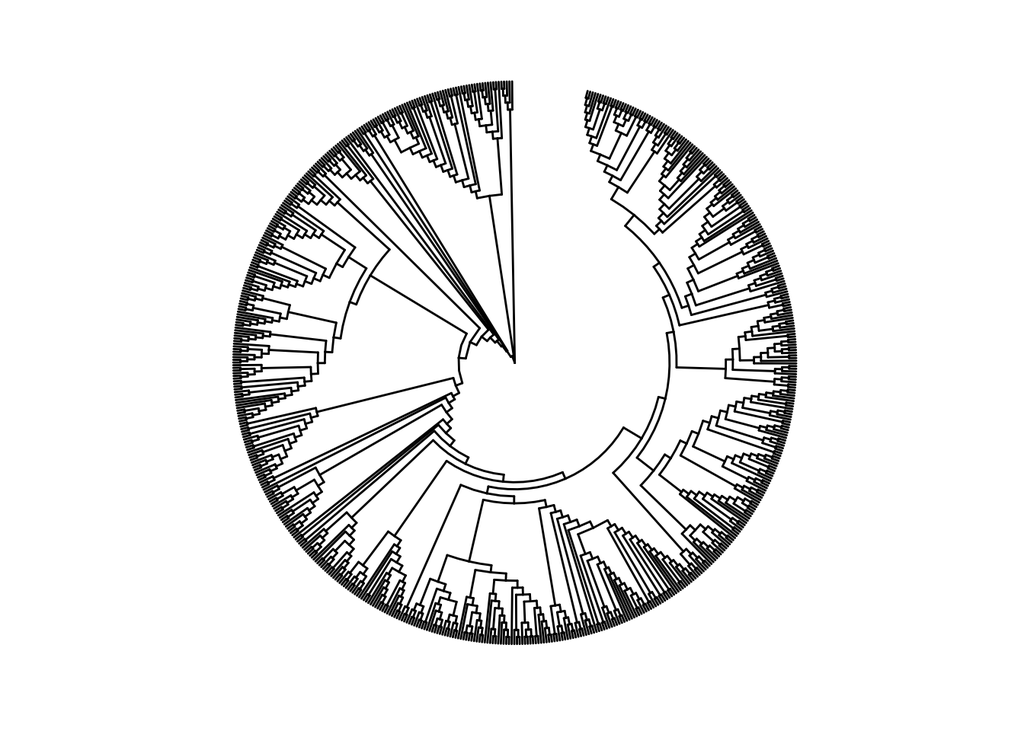

```r
# Plot with species without names
circ <- ggtree(tree, layout = "fan", open.angle = 15, branch.length = "none")
circ <- rotate_tree(circ, 90)
circ
```

```r
# Create a new plot with heatmap for each trait using a single scale
tree_data <- gheatmap(
  circ,
  Data,
  width = 0.2,
  offset = 0,  # Offset for placing the heatmap
  colnames_offset_x = 0,
  colnames_offset_y = 0,
  font.size = 0,
  hjust = 0
)
```

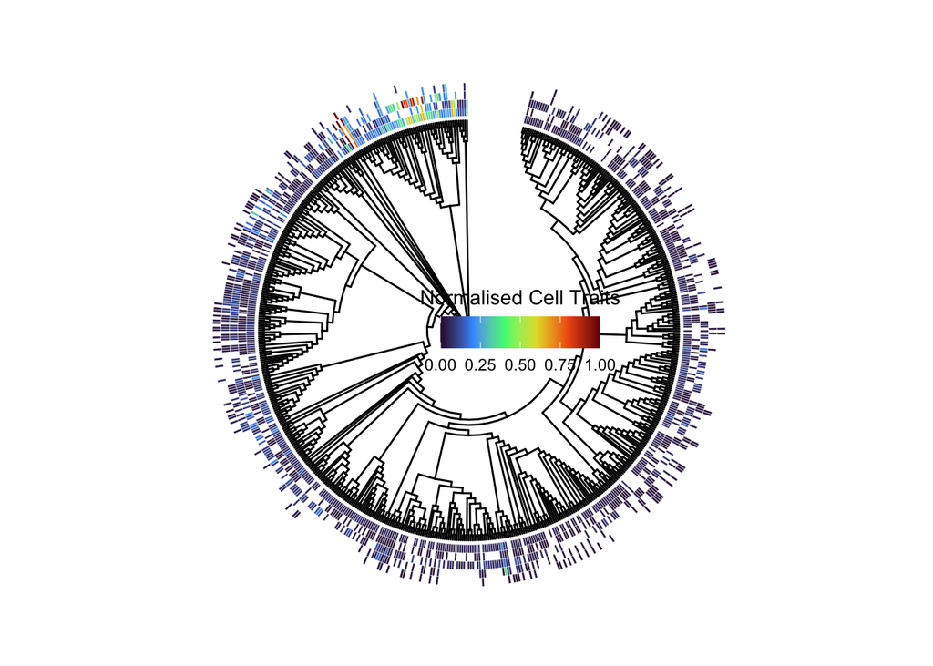

```r
# Apply the same scale for all traits
tree_data <- tree_data +
  scale_fill_viridis_c(option = "H", name = "Normalised Cell Traits", na.value = "white") +
  theme(
    legend.position = c(0.58, 0.5),
    legend.title.position = "top",
    legend.title.align = 0.5,
    legend.direction = "horizontal",
    legend.background = element_rect(fill = "transparent", color = NA),
    legend.key = element_rect(fill = "transparent", color = NA),
    legend.box.background = element_rect(fill = "transparent", color = NA),
    panel.background = element_rect(fill = "transparent", color = NA),
    plot.background = element_rect(fill = "transparent", color = NA),
    panel.grid.major = element_blank(),
    panel.grid.minor = element_blank()
  )

tree_data
```

```r
ggsave("../manuscript/Figure_2.png", tree_data, width = 12, height = 12,)
ggsave("../manuscript/Figure_2.pdf", tree_data, width = 12, height = 12)
```

```r
# Plot with species names
circ_names <- ggtree(tree, layout = "fan", open.angle = 15) +
  geom_tiplab(offset = 0.22, hjust = 0, size = 0.8)
circ_names <- rotate_tree(circ_names, 90)
```

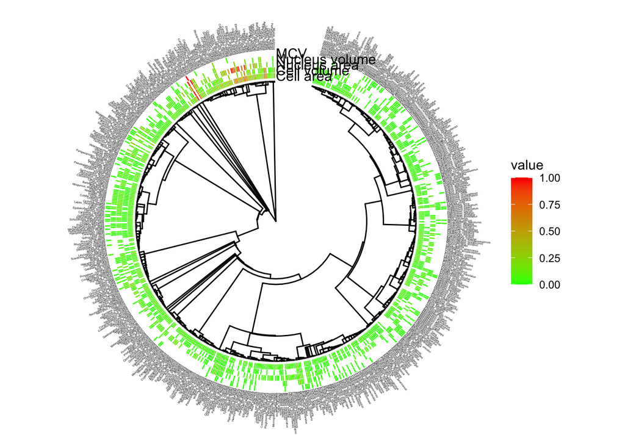

```r
# Create a new plot with heatmap for each trait using a single scale
tree_data_names <- gheatmap(
  circ_names,
  Data,
  width = 0.2,
  offset = 0,  # Offset for placing the heatmap
  colnames_offset_x = 0,
  colnames_offset_y = 0,
  font.size = 4,
  hjust = 0
)
tree_data_names
```

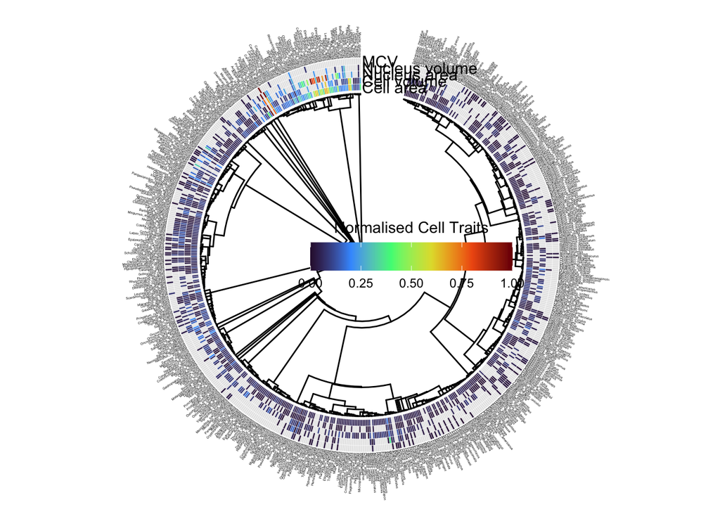

```r
# Apply the same scale for all traits
tree_data_names <- tree_data_names +
  scale_fill_viridis_c(option = "H", name = "Normalised Cell Traits", na.value = "grey90") +
  theme(
    legend.position = c(0.6, 0.5),
    legend.title.position = "top",
    legend.title.align = 0.5,
    legend.direction = "horizontal",
    legend.key = element_blank(),
    legend.background=element_blank(),
    legend.key.width = unit(1, "cm"),
    legend.key.height = unit(0.7, "cm")
  )

tree_data_names
```

# Most common species in the database

```r
# Counting Studies Per Species
species_by_studies <- dat %>%
  group_by(species) %>%
  summarise(num_studies = n_distinct(key)) %>%
  arrange(desc(num_studies)) %>%
  slice_head(n = 15)  # Limit to top 15 species based on the number of studies

plot_studies <- ggplot(species_by_studies, aes(x = reorder(species, num_studies), y = num_studies)) +
  geom_bar(stat = "identity", fill = "#00AFBB", width = 0.7) +
  coord_flip() +
  theme_pubr() +
  labs(
    x = "Species",
    y = "Number of Studies"
  ) +
  theme(
    axis.title.x = element_text(face = "bold", size = 12),
    axis.title.y = element_text(face = "bold", size = 12),
    axis.text.y = element_text(size = 10, face = "italic")  # Italicise species names
  )
# ------------------------------------------------------------------------------
# Counting Records per Species
species_by_records <- dat %>%
  group_by(species) %>%
  summarise(num_records = n()) %>%
  arrange(desc(num_records)) %>%
  slice_head(n = 15)  # Limit to top 15 species based on the number of records

plot_records <- ggplot(species_by_records, aes(x = reorder(species, num_records), y = num_records)) +
  geom_bar(stat = "identity", fill = "#009E73", width = 0.7) +
  coord_flip() +
  theme_pubr() +
  labs(
    x = "Species",
    y = "Number of Records"
  ) +
  theme(
    axis.title.x = element_text(face = "bold", size = 12),
    axis.title.y = element_text(face = "bold", size = 12),
    axis.text.y = element_text(size = 10, face = "italic")  # Italicise species names
  )
```

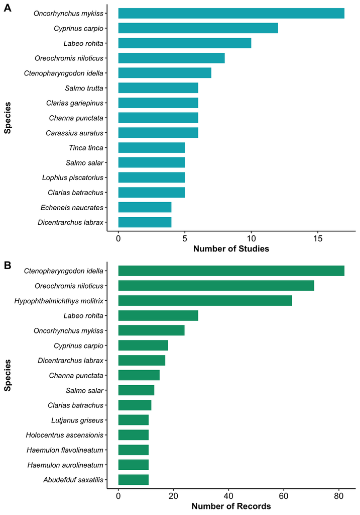

```r
plot_grid(
  plot_studies,
  plot_records,
  labels = c("A", "B"),
  nrow = 2,
  ncol = 1,
  label_size = 15,
  align = "hv"
)
```

# Number of species and percentage by Order

```r
#
n_spp <- dat %>%
  distinct(species) %>%
  nrow()
n_spp
```

```
## [1] 660
```

```r
# cousnting the most m¡common species
dat %>%
  group_by(species) %>%
  summarise(num_studies = n_distinct(key)) %>%
  arrange(desc(num_studies)) %>%
  slice_head(n = 15)  # Limit to top 15 species based on the number of studies
```

```
## # A tibble: 15 × 2
##    species                 num_studies
##    <chr>                         <int>
##  1 Oncorhynchus mykiss              17
##  2 Cyprinus carpio                  12
##  3 Labeo rohita                     10
##  4 Oreochromis niloticus             8
##  5 Ctenopharyngodon idella           7
##  6 Carassius auratus                 6
##  7 Channa punctata                   6
##  8 Clarias gariepinus                6
##  9 Salmo trutta                      6
## 10 Clarias batrachus                 5
## 11 Lophius piscatorius               5
## 12 Salmo salar                       5
## 13 Tinca tinca                       5
## 14 Dicentrarchus labrax              4
## 15 Echeneis naucrates                4
```

```r
# ------------------------------------------------------------------------------
# Counting records by species
dat %>%
  group_by(species) %>%
  summarise(num_records = n()) %>%
  arrange(desc(num_records)) %>%
  slice_head(n = 15)  # Limit to top 15 species based on the number of records
```

```
## # A tibble: 15 × 2
##    species                     num_records
##    <chr>                             <int>
##  1 Ctenopharyngodon idella              82
##  2 Oreochromis niloticus                71
##  3 Hypophthalmichthys molitrix          63
##  4 Labeo rohita                         29
##  5 Oncorhynchus mykiss                  24
##  6 Cyprinus carpio                      18
##  7 Dicentrarchus labrax                 17
##  8 Channa punctata                      15
##  9 Salmo salar                          13
## 10 Clarias batrachus                    12
## 11 Abudefduf saxatilis                  11
## 12 Haemulon aurolineatum                11
## 13 Haemulon flavolineatum               11
## 14 Holocentrus ascensionis              11
## 15 Lutjanus griseus                     11
```

```r
# ------------------------------------------------------------------------------
# Number of species and percentage by Order
spp_order <- dat %>%
  group_by(class, order) %>%
  reframe(count_species_by_order = length(unique(species)),
          percent_species_by_order = round(count_species_by_order/n_spp * 100, 2)) %>%
  ungroup() %>%
  arrange(desc(count_species_by_order)) %>%
slice_head(n = 15)  # Limit to top 15 species based on the number of studies
spp_order
```

```
## # A tibble: 15 × 4
##    class          order            count_species_by_order percent_species_by_o…¹
##    <chr>          <chr>                             <int>                  <dbl>
##  1 Actinopterygii Perciformes                         115                  17.4
##  2 Actinopterygii Cypriniformes                        51                   7.73
##  3 Actinopterygii Tetraodontiform…                     29                   4.39
##  4 Actinopterygii Labriformes                          27                   4.09
##  5 Actinopterygii Carangiformes                        24                   3.64
##  6 Actinopterygii Siluriformes                         24                   3.64
##  7 Actinopterygii Spariformes                          23                   3.48
##  8 Actinopterygii Pleuronectiform…                     20                   3.03
##  9 Chondrichthyes Carcharhiniform…                     20                   3.03
## 10 Actinopterygii Gadiformes                           19                   2.88
## 11 Actinopterygii Salmoniformes                        17                   2.58
## 12 Actinopterygii Syngnathiformes                      17                   2.58
## 13 Actinopterygii Characiformes                        15                   2.27
## 14 Actinopterygii Lutjaniformes                        15                   2.27
## 15 Actinopterygii Clupeiformes                         13                   1.97
## # ℹ abbreviated name: ¹percent_species_by_order
```

```r
# ------------------------------------------------------------------------------
plot_orders_numb <- ggplot(spp_order, aes(x = reorder(order, count_species_by_order), y = count_species_by_order)) +
  geom_bar(stat = "identity", fill = "#00AFBB", width = 0.7) +
  coord_flip() +
  theme_pubr() +
  labs(
    x = "Order",
    y = "Number of Species"
  ) +
  theme(
    axis.title.x = element_text(face = "bold", size = 14),
    axis.title.y = element_text(face = "bold", size = 14))
# ------------------------------------------------------------------------------
plot_orders_perc <- ggplot(spp_order, aes(x = reorder(order, percent_species_by_order), y = percent_species_by_order)) +
  geom_bar(stat = "identity", fill = "#00AFBB", width = 0.7) +
  coord_flip() +
  theme_pubr() +
  labs(
    x = "Order",
    y = "Percentage of representation in ErythroCite"
  ) +
  theme(
    axis.title.x = element_text(face = "bold", size = 14),
    axis.title.y = element_text(face = "bold", size = 14))
```

From a taxonomic perspective, Perciformes represented 17.4% (115 species) of the species contained in our database, followed by Cypriniformes (7.73%, 51 species), Tetraodontiformes (4.39%, 29 species) and Labriformes (4.09%, 27 species). The remaining orders had a lower representation, with 24 or fewer species each, accounting for less than 4% of the species in our database. Of the top 15 most represented fish orders, 14 belonged to bony fishes and only one to cartilaginous fishes (Carcharhiniformes).

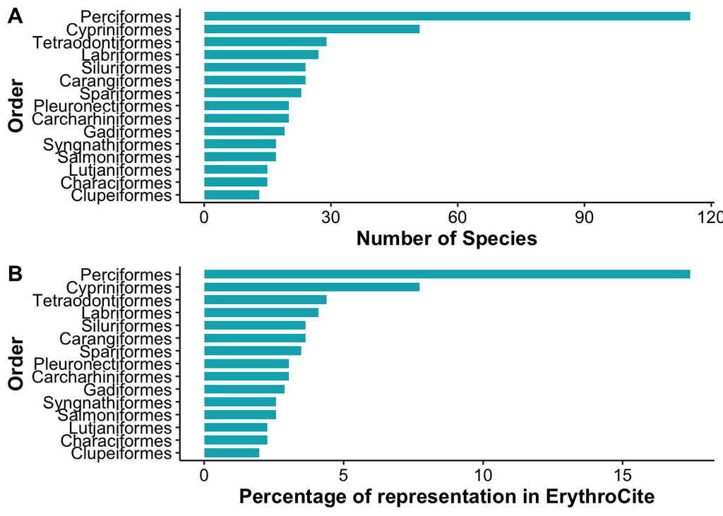

```r
plot_grid(
  plot_orders_numb,
  plot_orders_perc,
  labels = c("A", "B"),
  nrow = 2,
  ncol = 1,
  label_size = 15
)
```

# Studies and metadata

```r
# Counting Studies Per Life Stage
life_stage_by_studies <- dat %>%
  mutate(life_stage = ifelse(is.na(life_stage), "not reported", life_stage)) %>%
  group_by(life_stage) %>%
  summarise(num_studies = n_distinct(key)) %>%
  arrange(desc(num_studies))

# Plotting Studies by Life Stage
plot_life_stages <- ggplot(life_stage_by_studies, aes(x = reorder(life_stage, num_studies), y = num_studies)) +
  geom_bar(stat = "identity", fill = "#00AFBB", width = 0.7) +
  coord_flip() +
  theme_pubr() +
  labs(
    x = "Life Stage",
    y = "Number of Studies"
  ) +
  theme(
    axis.title.x = element_text(face = "bold", size = 12),
    axis.title.y = element_text(face = "bold", size = 12),
    axis.text.y = element_text(size = 10)  # Adjust font size for life stage names
  )

# ------------------------------------------------------------------------------
# Counting Studies Per Sex
sex_by_studies <- dat %>%
  mutate(sex = ifelse(is.na(sex), "not reported", sex)) %>%
  group_by(sex) %>%
  summarise(num_studies = n_distinct(key)) %>%
  arrange(desc(num_studies))

# Plotting Studies by Sex
plot_sex <- ggplot(sex_by_studies, aes(x = reorder(sex, num_studies), y = num_studies)) +
  geom_bar(stat = "identity", fill = "#00AFBB", width = 0.7) +
  coord_flip() +
  theme_pubr() +
  labs(
    x = "Sex",
    y = "Number of Studies"
  ) +
  theme(
    axis.title.x = element_text(face = "bold", size = 12),
    axis.title.y = element_text(face = "bold", size = 12),
    axis.text.y = element_text(size = 10)  # Adjust font size for sex labels
  )
# ------------------------------------------------------------------------------
# Counting Studies Per Realm
realm_by_studies <- dat %>%
  group_by(realm) %>%
  summarise(num_studies = n_distinct(key)) %>%
  arrange(desc(num_studies))

# Plotting Studies by Realm
plot_realm <- ggplot(realm_by_studies, aes(x = reorder(realm, num_studies), y = num_studies)) +
  geom_bar(stat = "identity", fill = "#00AFBB", width = 0.7) +
  coord_flip() +
  theme_pubr() +
  labs(
    x = "Realms",
    y = "Number of Studies"
  ) +
  theme(
    axis.title.x = element_text(face = "bold", size = 12),
    axis.title.y = element_text(face = "bold", size = 12),
    axis.text.y = element_text(size = 10)  # Adjust font size for realm labels
  )
```

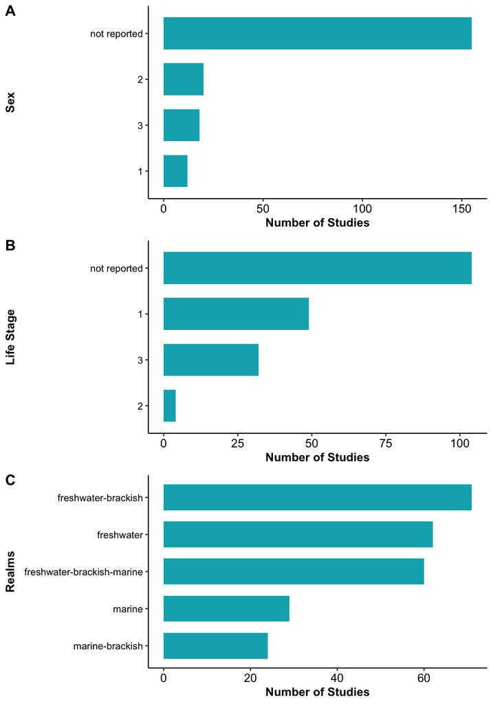

```r
plot_grid(
  plot_sex,
  plot_life_stages,
  plot_realm,
  labels = c("A", "B", "C"),
  nrow = 3,
  ncol = 1,
  label_size = 15,
  align = "hv"
)
```

# Figure_3: Cell size traits

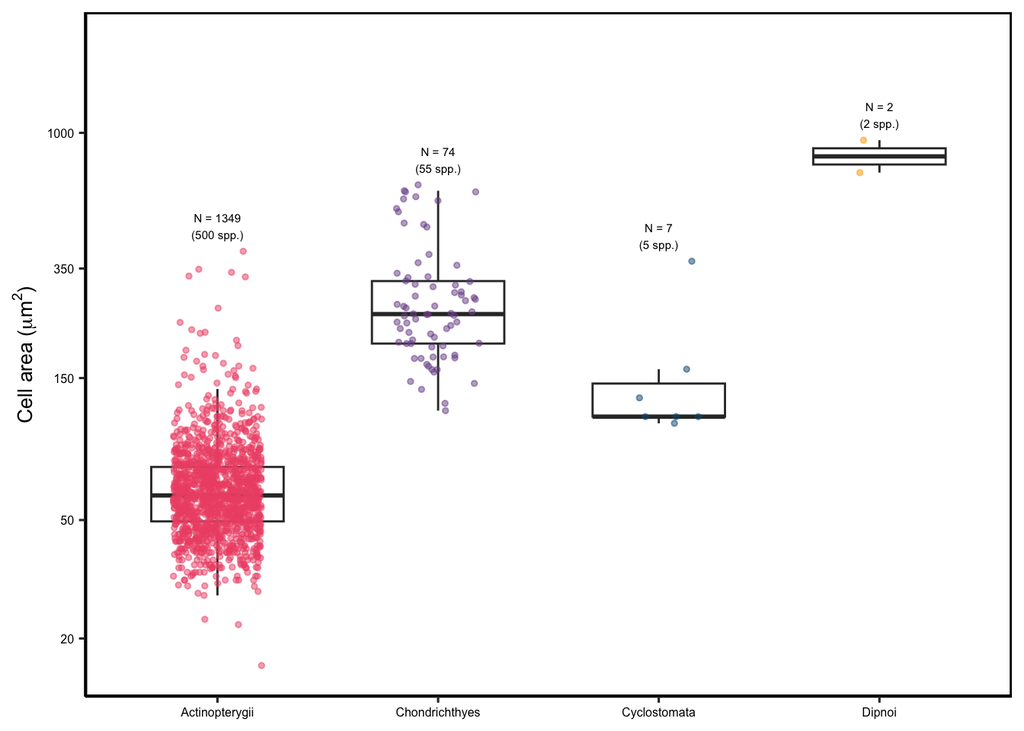

```r
# Define colors for each class
cols_class <- c("Actinopterygii"    = "#ef5675",
                "Chondrichthyes"    = "#7a5195",
                "Cyclostomata"      = "#075983",
                "Dipnoi"            = "#ffa600")
# ------------------------------------------------------------------------------
# Clean the data for cell area
dat_clean_cell_area <- dat %>%
  filter(!is.na(cell_area))

# Calculate summary statistics of cell area for each class
df_summary <- dat_clean_cell_area %>%
  group_by(class) %>%
  summarise(
    n_species = n_distinct(species),
    n_obs = n(),
    max_y_cell_area = max(cell_area, na.rm = TRUE))

# Plot for Cell Area
plot_cell_area <- ggplot(dat_clean_cell_area, aes(x = class, y = cell_area, fill = class)) +
  geom_boxplot(width = 0.6,
               fill = "white",
               outlier.shape = NA) +
  geom_text(data = df_summary,
            aes(y = max_y_cell_area, label = paste0("N = ", n_obs, "\n(", n_species, " spp.)")),
            vjust = -0.5, size = 2) +
  theme_pubr() +
  theme(
    legend.position = "none",
    axis.text.x = element_text(size = 6),
    axis.text.y = element_text(size = 6),
    axis.title.x = element_blank(),
    axis.title.y = element_text(size = 10),
    panel.border = element_rect(colour = "black", fill = NA, linewidth = 1)
  ) +
  labs(y = expression("Cell area (" * mu * m^2 * ")")) +
  scale_y_log10(
    breaks = c(10, 20, 50, 150, 350, 1000),
    limits = c(NA, 2000)
  ) +
  scale_fill_manual(values = cols_class) +  # For boxplot fill
  scale_color_manual(values = cols_class) +
  geom_point(
    aes(colour = class),
    size = 1,
    alpha = .5,
    position = position_jitter(
      seed = 1, width = .2
    ))

plot_cell_area
```

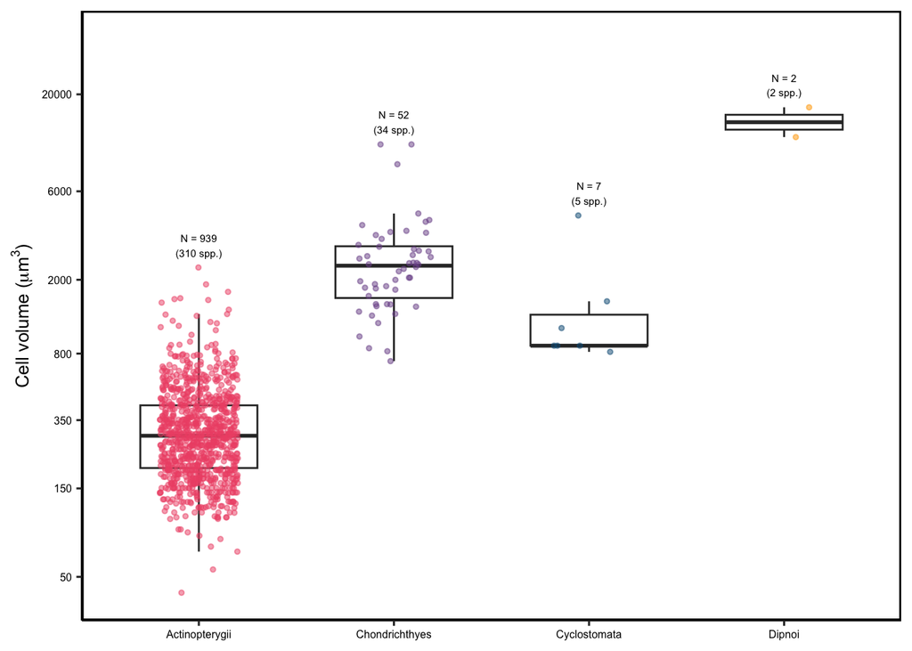

```r
# ------------------------------------------------------------------------------
# Clean the data for cell volume
dat_clean_cell_volume <- dat %>%
  filter(!is.na(cell_volume))

# Calculate summary statistics of cell area for each class
df_summary <- dat_clean_cell_volume %>%
  group_by(class) %>%
  summarise(
    n_species = n_distinct(species),
    n_obs = n(),
    max_y_cell_volume = max(cell_volume, na.rm = TRUE))

# Plot for Cell Volume
plot_cell_volume <- ggplot(dat_clean_cell_volume, aes(x = class, y = cell_volume, fill = class)) +
  geom_boxplot(width = 0.6,
               fill = "white",
               outlier.shape = NA) +
  geom_text(data = df_summary,
            aes(y = max_y_cell_volume, label = paste0("N = ", n_obs, "\n(", n_species, " spp.)")),
            vjust = -0.5, size = 2) +
  theme_pubr() +
  theme(
    legend.position = "none",
    axis.text.x = element_text(size = 6),
    axis.text.y = element_text(size = 6),
    axis.title.x = element_blank(),
    axis.title.y = element_text(size = 10),  # Reduce font size of the y-axis title
    panel.border = element_rect(colour = "black", fill = NA, linewidth = 1)
  ) +
  labs(y = expression("Cell volume (" * mu * m^3 * ")")) +
  scale_y_log10(
    breaks = c(10, 20, 50, 150, 350, 800, 2000, 6000, 20000),
    limits = c(NA, 40000)
  ) +
  scale_fill_manual(values = cols_class) +  # For boxplot fill
  scale_color_manual(values = cols_class) +
  geom_point(
    aes(colour = class),
    size = 1,
    alpha = .5,
    position = position_jitter(
      seed = 1, width = .2
    ))
plot_cell_volume
```